# RED WINE QUALITY EDA PROJECT by David Gonsalves

```
## 'data.frame':    1599 obs. of  13 variables:
##  $ X                   : int  1 2 3 4 5 6 7 8 9 10 ...
##  $ fixed.acidity       : num  7.4 7.8 7.8 11.2 7.4 7.4 7.9 7.3 7.8 7.5 ...
##  $ volatile.acidity    : num  0.7 0.88 0.76 0.28 0.7 0.66 0.6 0.65 0.58 0.5 ...
##  $ citric.acid         : num  0 0 0.04 0.56 0 0 0.06 0 0.02 0.36 ...
##  $ residual.sugar      : num  1.9 2.6 2.3 1.9 1.9 1.8 1.6 1.2 2 6.1 ...
##  $ chlorides           : num  0.076 0.098 0.092 0.075 0.076 0.075 0.069 0.065 0.073 0.071 ...
##  $ free.sulfur.dioxide : num  11 25 15 17 11 13 15 15 9 17 ...
##  $ total.sulfur.dioxide: num  34 67 54 60 34 40 59 21 18 102 ...
##  $ density             : num  0.998 0.997 0.997 0.998 0.998 ...
##  $ pH                  : num  3.51 3.2 3.26 3.16 3.51 3.51 3.3 3.39 3.36 3.35 ...
##  $ sulphates           : num  0.56 0.68 0.65 0.58 0.56 0.56 0.46 0.47 0.57 0.8 ...
##  $ alcohol             : num  9.4 9.8 9.8 9.8 9.4 9.4 9.4 10 9.5 10.5 ...
##  $ quality             : int  5 5 5 6 5 5 5 7 7 5 ...
```

```
##        X          fixed.acidity   volatile.acidity  citric.acid
##  Min.   :   1.0   Min.   : 4.60   Min.   :0.1200   Min.   :0.000
##  1st Qu.: 400.5   1st Qu.: 7.10   1st Qu.:0.3900   1st Qu.:0.090
##  Median : 800.0   Median : 7.90   Median :0.5200   Median :0.260
##  Mean   : 800.0   Mean   : 8.32   Mean   :0.5278   Mean   :0.271
##  3rd Qu.:1199.5   3rd Qu.: 9.20   3rd Qu.:0.6400   3rd Qu.:0.420
##  Max.   :1599.0   Max.   :15.90   Max.   :1.5800   Max.   :1.000
##  residual.sugar     chlorides       free.sulfur.dioxide
##  Min.   : 0.900   Min.   :0.01200   Min.   : 1.00
##  1st Qu.: 1.900   1st Qu.:0.07000   1st Qu.: 7.00
##  Median : 2.200   Median :0.07900   Median :14.00
##  Mean   : 2.539   Mean   :0.08747   Mean   :15.87
##  3rd Qu.: 2.600   3rd Qu.:0.09000   3rd Qu.:21.00
##  Max.   :15.500   Max.   :0.61100   Max.   :72.00
##  total.sulfur.dioxide    density             pH          sulphates
##  Min.   :  6.00       Min.   :0.9901   Min.   :2.740   Min.   :0.3300
##  1st Qu.: 22.00       1st Qu.:0.9956   1st Qu.:3.210   1st Qu.:0.5500
##  Median : 38.00       Median :0.9968   Median :3.310   Median :0.6200
##  Mean   : 46.47       Mean   :0.9967   Mean   :3.311   Mean   :0.6581
##  3rd Qu.: 62.00       3rd Qu.:0.9978   3rd Qu.:3.400   3rd Qu.:0.7300
##  Max.   :289.00       Max.   :1.0037   Max.   :4.010   Max.   :2.0000
##     alcohol         quality
##  Min.   : 8.40   Min.   :3.000
##  1st Qu.: 9.50   1st Qu.:5.000
##  Median :10.20   Median :6.000
##  Mean   :10.42   Mean   :5.636
##  3rd Qu.:11.10   3rd Qu.:6.000
##  Max.   :14.90   Max.   :8.000
```

```
##  Ord.factor w/ 6 levels "3"<"4"<"5"<"6"<..: 3 3 3 4 3 3 3 5 5 3 ...
```

```
##   3   4   5   6   7   8
##  10  53 681 638 199  18
```

# EDA pertaining to Red Wine Quality.

The winQR dataset consists of tested chemical & physical properties (inputs) and sensory (the output) variables related to red and white variants of the Portuguese “Vinho Verde” wine. A total of 1,599 wines were tested. Note: there is no data about grape types, wine brand, wine selling price, etc. The inputs include objective tests (e.g. PH values) and the output is based on sensory data (median of evaluations made by three wine experts). Each expert graded the wine quality between 0 (very bad) and 10 (very excellent). Description of variables: Input variables (based on tested chemical and physical properties): 1 - fixed acidity (tartaric acid - g / dm^3) 2 - volatile acidity (acetic acid - g / dm^3) 3 - citric acid (g / dm^3) 4 - residual sugar (g / dm^3) 5 - chlorides (sodium chloride - g / dm^3 6 - free sulfur dioxide (mg / dm^3) 7 - total sulfur dioxide (mg / dm^3) 8 - density (g / cm^3) 9 - pH 10 - sulphates (potassium sulphate - g / dm^3) 11 - alcohol (% by volume) Output variable (based on sensory data): 12 - quality (score between 0 and 10)

Dataset source: P. Cortez, A. Cerdeira, F. Almeida, T. Matos and J. Reis. [2009] Modeling wine preferences by data mining from physicochemical properties. In Decision Support Systems, Elsevier, 47(4):547-553. ISSN: 0167-9236.

# Univariate Plots Section

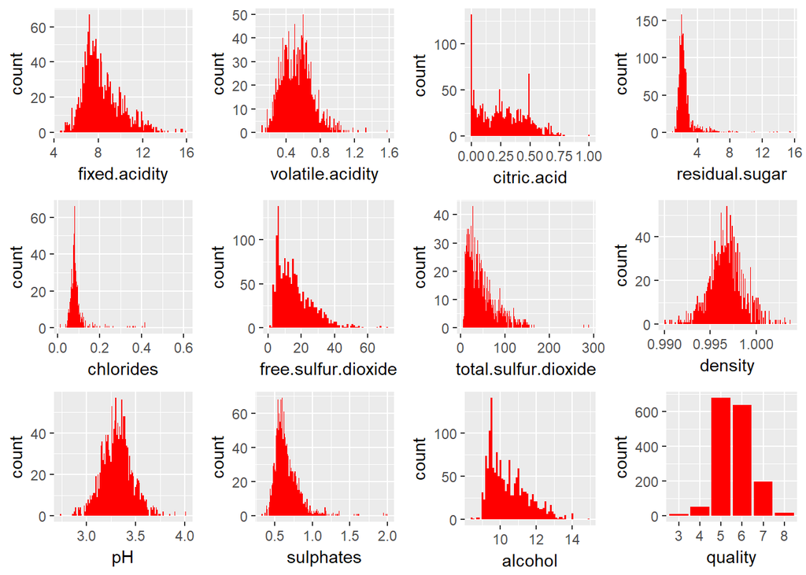

The following data pattern for each chemical, physical, or sensory property were observed:

- Normally distributed properties: density; PH; quality
- Long tailed properties: fixed acidity; volatile acidity; free sulfur; total sulfur; alcohol
- Bimodal property: citric acid
- Properties with significant outliers: residual sugar; chlorides; sulphates

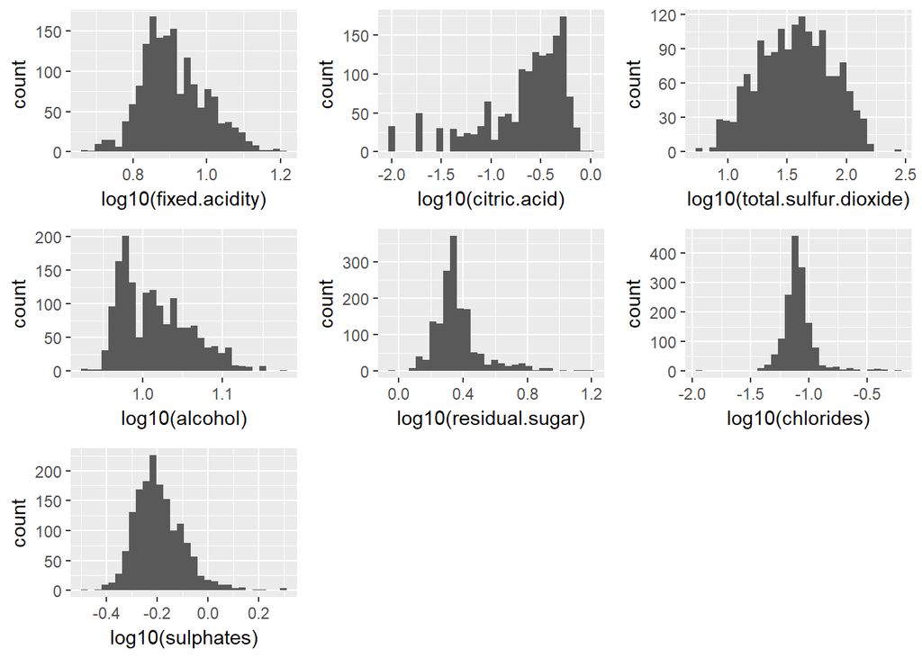

The summary(wineQR$quality) results indicate a potential convenience for introducing a new variable to combine the wine quality into groups, as follows: low (quality 3 or 4), medium (5 or 6), and high (7 or 8)

```
##    low (3-4) medium (5-6)   high (7-8)
##           63         1319          217
```

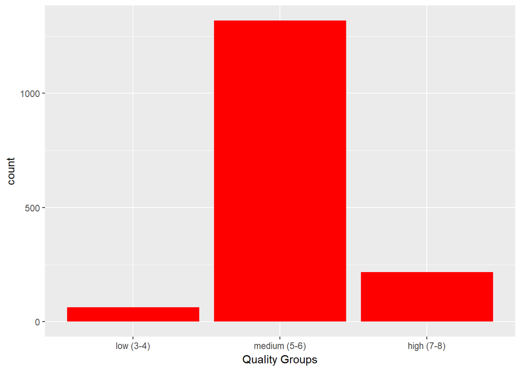

# Univariate Analysis

Questions for Relection:

### What is the structure of the dataset?

After conversion from csv the structure of the wineQR dataset is a dataframe in wide format. An additional variable was added to group the quality data.

### What is/are the main feature(s) of interest in the dataset?

The main features of the dataset are: 1. All the wines are red and were produced as wine type “vinho verde” which indicates the wines originate from a particular region in Portugal, are not aged, and exhibit a slight effervescence. 2. The data for each wine contains 10 chemical properties, one physical property (density), and one sensory property (quality). 3. My main interest is to investigate Which chemical and physical properties influence the quality of this type of red wine?

### What other features in the dataset will help support the investigation?

The sensory score for each wine is the median of at least 3 evaluations made by wine experts, a traditional way of evaluating wines. This feature provides a subjective, consensus measure to lend some credence to any findings.

### Did you create any new variables from existing variables in the dataset?

To simplfiy the analysis I introduced a new variable grouping the quality data into Q.group with values low (3-4), medium (5-6), and high (7-8).

### Of the features you investigated, were there any unusual distributions?

# Bivariate Plots Section

The Univariate analysis indicate some wine properties of interest namely, citric acid, sulphates, an alcohol but did not illuminate any relationships between properties. My next step was to employ the ggpairs function to pair sets of variables in the wineQR dataset in order to uncover possible interrelationships between the properties.

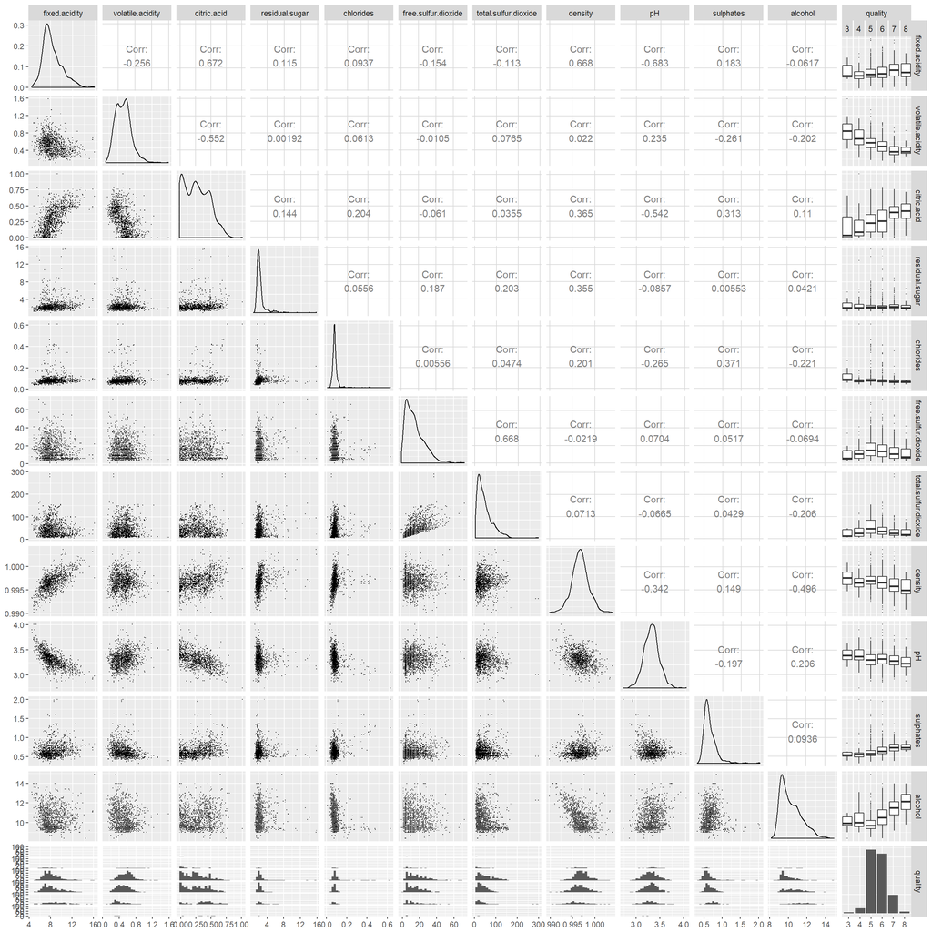

The ggpairs plot indicates that correlations between many of the wine properties are weak. Fixed acidity and volatile acidity seem to be somewhat inversely correlated. Clearly pH is expected to be inversely related with acidity since pH is a measure of acidity [1(strong) - 6(weak)], distilled water [7(neutral)], basicity [8(weak) - 14(strong)]. Although there is separate data for fixed, volatile, and citric acids the correlation data, and common sense, indicate that these measures probably overlap. There also seems to be a positive correlation between density and acidity. Since density is a physical property and acidity a chemical property intuitively more wine molecules would carry more acid components.

In summary, ggpairs boxplots seem to be more useful in terms of addressing the central question regaring how the various properties influence the perceived quality of the wines. Therefore I focused on studying the boxplots more closely.

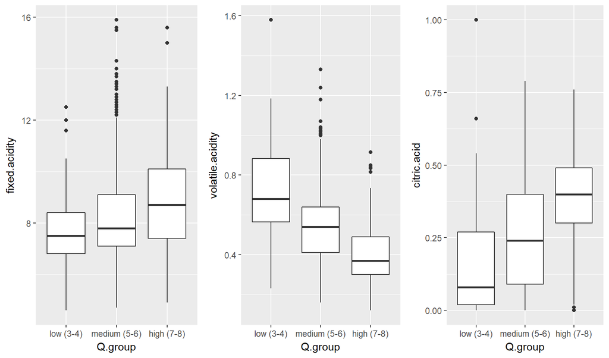

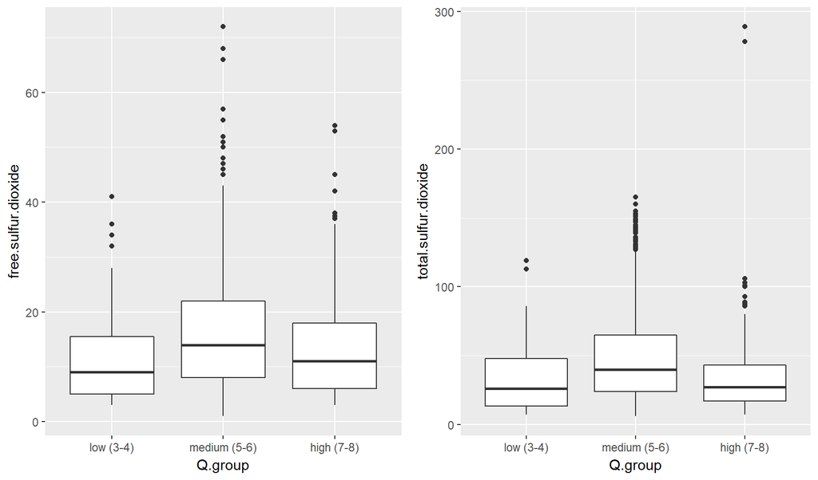

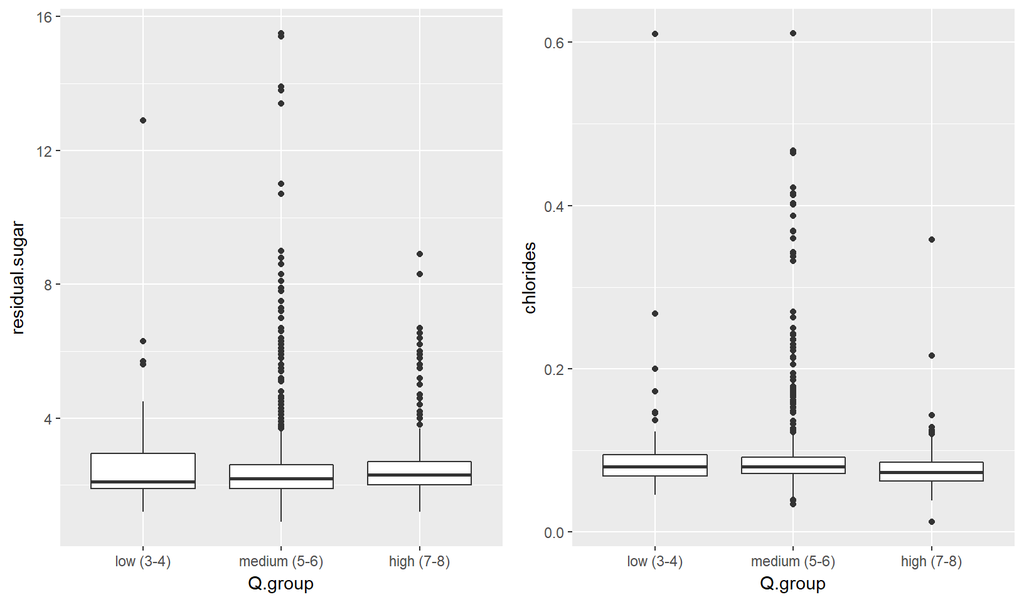

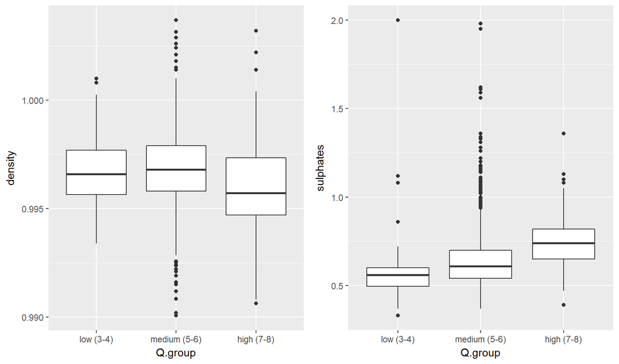

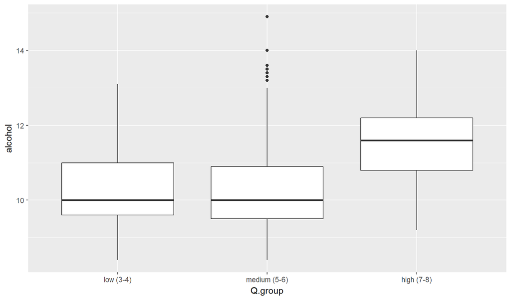

I confirmed with these plots that measures of fixed acidity and volatile acidity seem to counterbalance each other. On the other hand, citric acid seems to play a more signifiant role in distinguising the higher quality wines. To further condense my findings, I’ve decided to combine the fixed and volatile acidities together in a new variable labeled FaV.acidity.

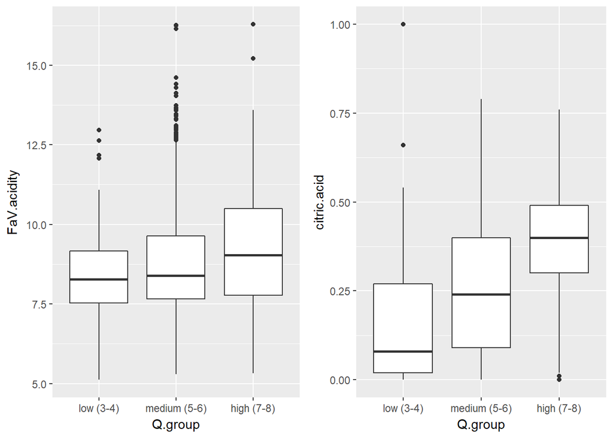

The boxplot investigations strengthend my expectation that citric acid, alcohol, and sulphates are likely good indicators for wine quality in this dataset. Consequently, I obtained quantitative summaries for these properties by quality group.

```
## Q.group: low (3-4)
## [1] 0.1736508
## --------------------------------------------------------
## Q.group: medium (5-6)
## [1] 0.2582638
## --------------------------------------------------------
## Q.group: high (7-8)
## [1] 0.3764977
```

```
## Q.group: low (3-4)
## [1] 10.21587
## --------------------------------------------------------
## Q.group: medium (5-6)
## [1] 10.25272
## --------------------------------------------------------
## Q.group: high (7-8)
## [1] 11.51805
```

```
## Q.group: low (3-4)
## [1] 0.5922222
## --------------------------------------------------------
## Q.group: medium (5-6)
## [1] 0.6472631
## --------------------------------------------------------
## Q.group: high (7-8)
## [1] 0.7434562
```

# Bivariate Analysis

The boxplots strengthen my expectation that citric acid, alcohol, and sulphates are likely good indicators for wine quality in this dataset. Consequently, I obtained quantitative summaries for these properties by quality group

### What are relationships I observed in this part of the investigation?

From the correlation coefficients in the ggpairs plot and from the subsequent boxplots it has become clear that there is a significant positive relationship between citric acid concentration and quality; between between alcohol content and quality; and between sulphates concentration and quality These relationships have very few outliers within the high quality group.

### What was the strongest relationships you found?

Comparing the quantitative summary statistics by quality group I see that for citric acid the proportional difference in means between medium and high qualities is (0.3765 - 0.2583)/0.2585 = 45.8% For alcohol acid the proportional difference in means between medium and high qualities is (11.52 - 10.25)/10.25 = 12.4% For sulphates the proportional difference in means between medium and high qualities is (0.7435 - 0.6473)/0.6473 = 14.9%

I conclude that citric acid is the most distinguishing factor in determining the “vinho verde” wine quality, followed by the percentage of sulphates, and then the concentration of alcohol Revisiting the ggpairs plot I note that the correlation coefficient between citric acid and sulphates is 0.313. So there does appears to be a weak relationship between these two properties.

### Did you observe any interesting relationships between the other features?

# Multivariate Plots Section

Given the findings above, I want to explore relationships between the properties that are the most promising for predicting wine quality.

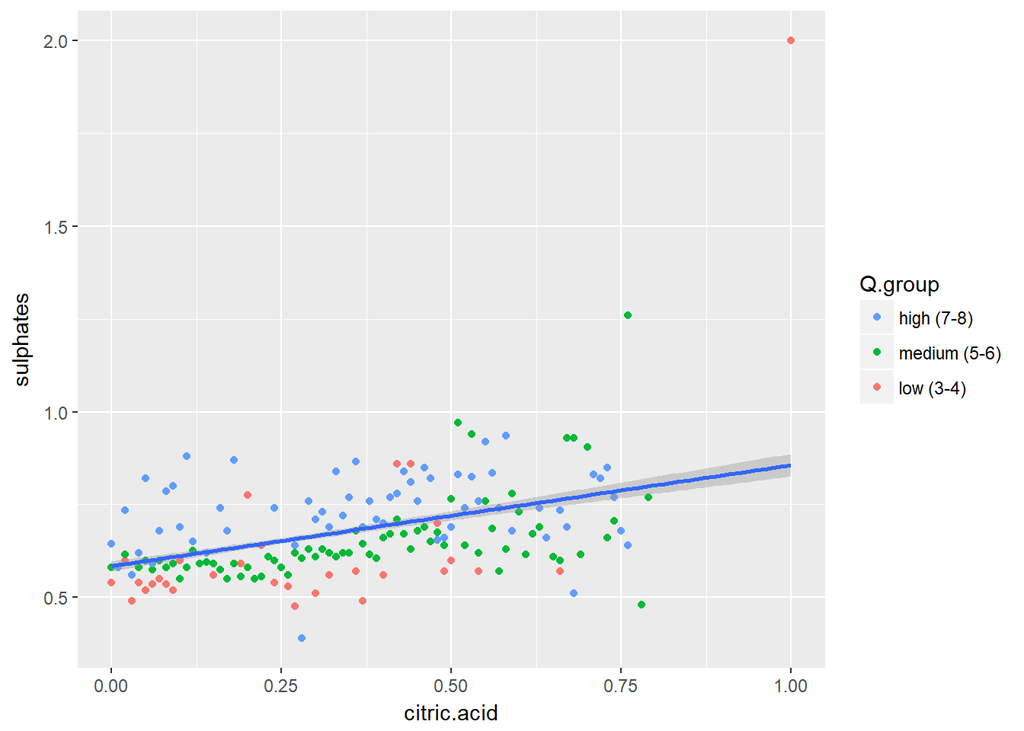

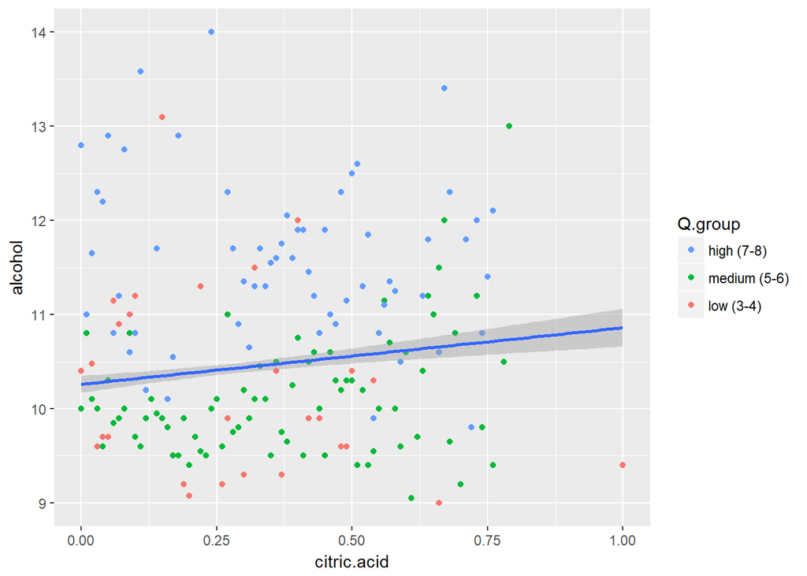

# Multivariate Analysis

Were there any interesting or surprising interactions between features? For all three groups of wine quality, the variations around the mean for alcohol content were quite pronounced. By contrast, the variations around the mean for sulphates were small. It appears that citric acid together with sulphate concentrations may be the reliable predictors of wine quality for this dataset. The standard error shading reiforces this opinion.

# Final Plots and Summary

### Plot One

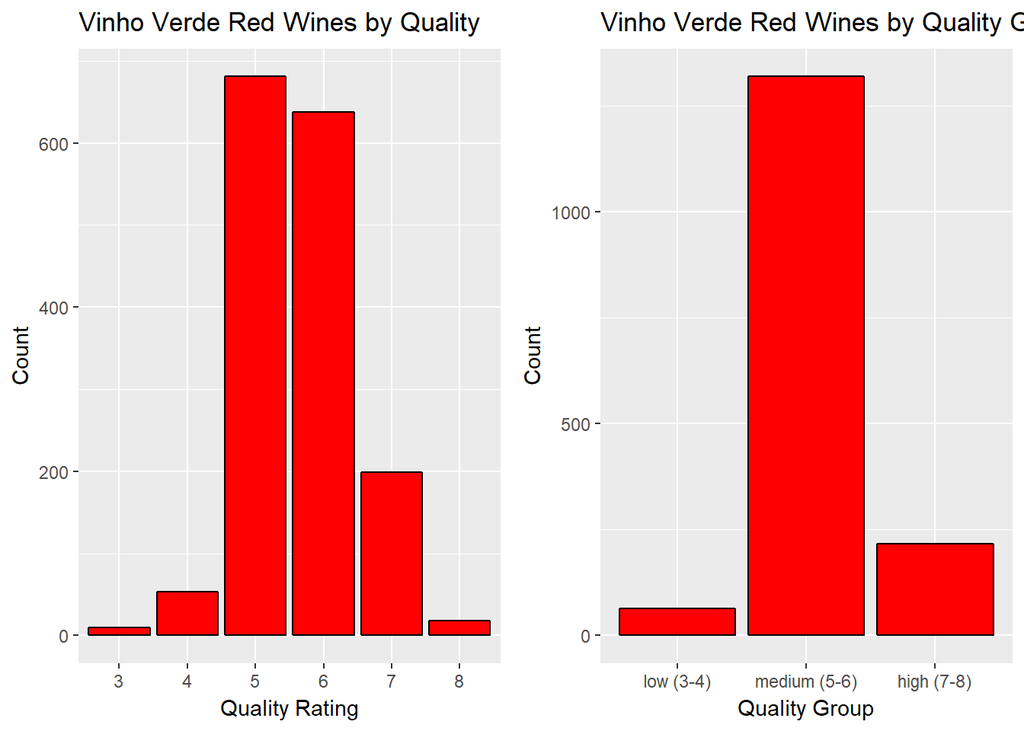

### Description One

My main interest for this EDA project is to investigate Which chemical and physical properties influence the quality of “vinho verde” red wines. The key starting point is to understand how the wine quality was measured. Evaluations were made by three wine experts. Each expert graded the wine quality between 0 (very bad) and 10 (very excellent). These bar charts show the counts for each quality grade in the dataset containing a total of 1,599 red wines. The second bar chart summarizes the quality into three groups namely, low (3-4), medium (5-6), and high (7-8). This grouping helps to simplify the analysis and the vizualizations.

### Plot Two

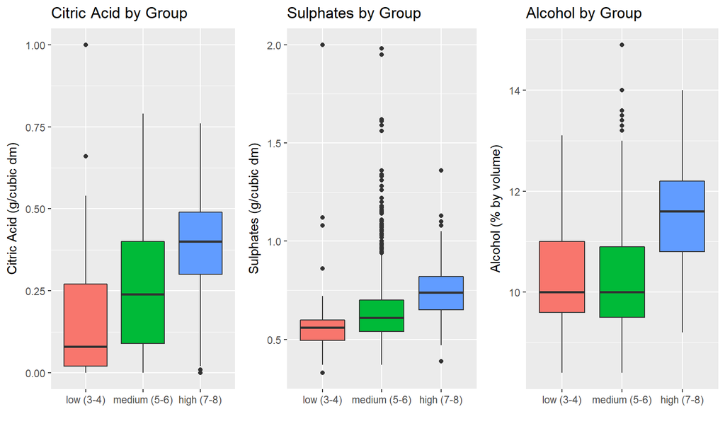

### Description Two

These plots clearly illustrate the significance of citrus, sulphates and alcohol as differentiators between the low, medium and high quality wines. When analyzing the boxplots it is important to note the differences between the y-scales. The quantitative analysis described earlier shows that the differences between the means of medium and high quality wines are 46% for citric acid; 15% for sulphates; and 12% for alcohol.

### Plot Three

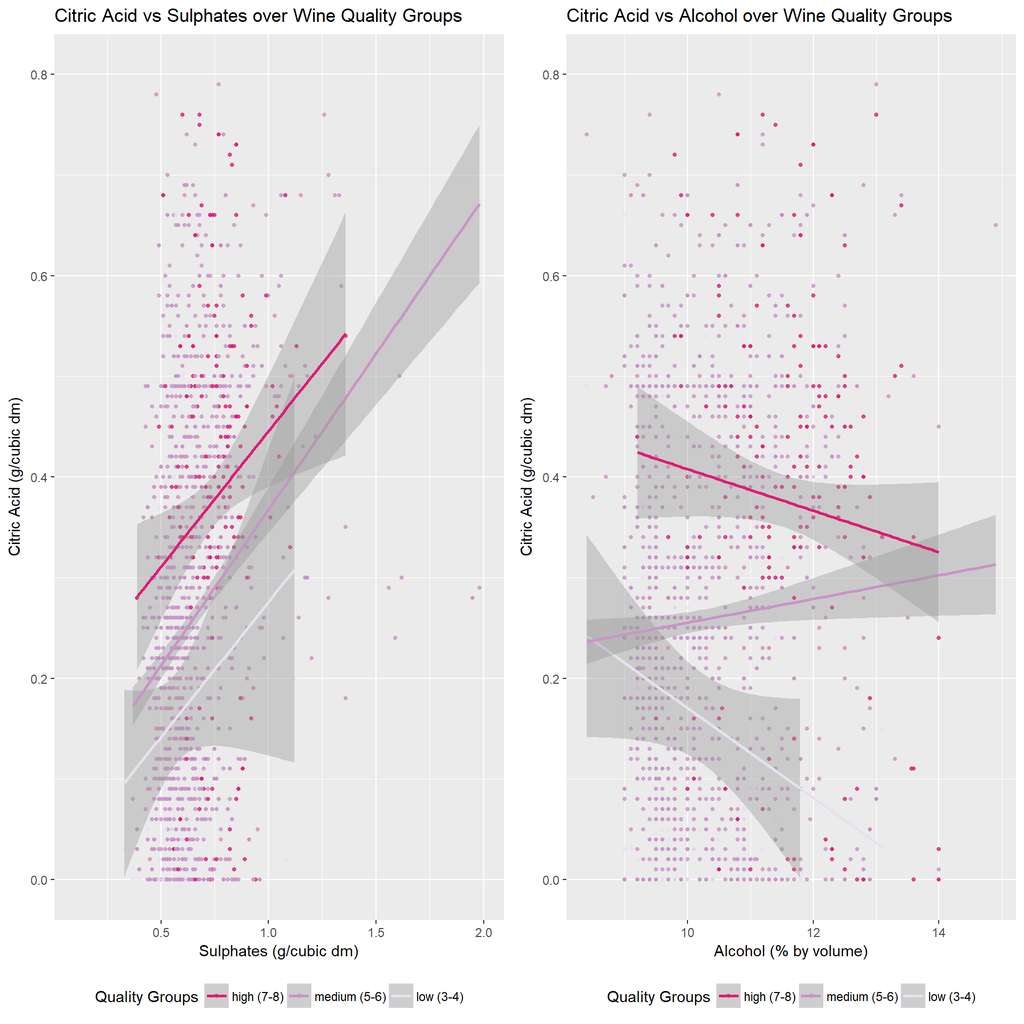

### Description Three

# Reflection

I’ve long been facinated by wine making - in particular what makes a wine good This dataset of 1,599 “vinho verde” red wines, containing 10 objective measures of important wine properties as well as expert wine quality rankings, gave me the opportunity to explore this question - using EDA techniques.

I think one good data analyst decision that helped me perform the analysis more easily and that enables the reader to better understand the results is to group the quality ratings into low (3-4), medium (5-6), and high (7-8). I’ve now a greater appreciation for the chemistry of wines and I’ve determined that three properties citric acid, sulphates, and alcohol are important components in the best “vinho verde”" wines.

However, coming up with some formula that could be used to predict, or to produce, a high quality “vinho verde” red wine has proven to be illusive, so far This begs the question, would a much bigger and wider dataset allow a researcher to draw more predictive conclusions? For example, California is renowned for consistently producing good wines, but in certain years similar European wines far surpass Californian wines in quality. Why? Experts attribute this difference to the relative consistency of California’s climate versus the more erratic European climate. So, weather conditions in a given season, soil composition, and grape varietals are also important factors in determining wine quality. Data on these factors should contribute to a more predictive model for wine quality.

My analysis, coupled with more general information about wine making, leads me to the view that the quality of wine, a product honed over thousands of years and evaluated by diverse palates, most likely cannot be reduced to any single scientific equation.